# Coding Outreach Group Summer Workshop - Visualizing Data in R

# —– Exercise —–

Using elements from plots we’ve looked at in this section create a plot with the following criteria: * x = Age.MOs * y = Correlation.fz * Mod = Valence.Pair * Using the calc theme * Using a grayscale Color Brewer palette

# 5.0. Examples of Visualizations w/ Qualitative Independent Variables

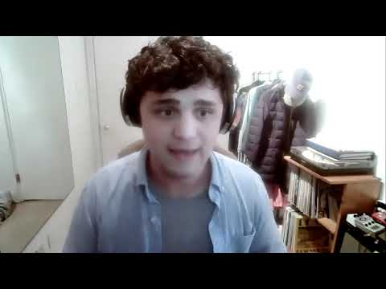

As we move into more complex, results-focused plotting, we’re going to switch to a slightly uglier dataset that’s better suited for many different analysis types.

```r
   load("C:/Users/Administrator/Google_Drive/COG/cog_summer_workshops_2021/data-visualization-in-r/Dataframes/df2.rda")
```

Once again, let’s take a look at the variables available to us:

```r
   describe(df)
```

|  | vars | n | mean | sd | median | trimmed | mad | min | max | range | skew | kurtosis | se |
| --- | --- | --- | --- | --- | --- | --- | --- | --- | --- | --- | --- | --- | --- |
| PID* | 1 | 1114 | 25.5377019749 | 14.0000294 | 25.0000000 | 25.566143498 | 16.3086000 | 1.000000 | 50.000000 | 49.000000 | 0.03638551 | -1.04014385 | 0.41945594 |
| Event | 2 | 1114 | 4.3016157989 | 2.9366870 | 4.0000000 | 4.263452915 | 4.4478000 | 0.000000 | 9.000000 | 9.000000 | 0.06302333 | -1.28124741 | 0.08798630 |
| Strategy* | 3 | 1114 | 2.0000000000 | 0.0000000 | 2.0000000 | 2.000000000 | 0.0000000 | 2.000000 | 2.000000 | 0.000000 | NaN | NaN | 0.00000000 |
| Emotion* | 4 | 1114 | 6.3985637343 | 3.8307684 | 5.0000000 | 6.144618834 | 4.4478000 | 1.000000 | 14.000000 | 13.000000 | 0.46940563 | -1.18779911 | 0.11477394 |
| Valence* | 5 | 1114 | 1.4587073609 | 0.4985158 | 1.0000000 | 1.448430493 | 0.0000000 | 1.000000 | 2.000000 | 1.000000 | 0.16551360 | -1.97437516 | 0.01493607 |
| Emo.Extent | 6 | 1114 | 5.6508078995 | 1.2399331 | 6.0000000 | 5.757847534 | 1.4826000 | 2.000000 | 7.000000 | 5.000000 | -0.57401189 | -0.47836613 | 0.03714973 |
| Emo.Extent.z | 7 | 1114 | 0.0199634532 | 0.9913642 | 0.2991532 | 0.105544895 | 1.1853838 | -2.898968 | 1.098684 | 3.997652 | -0.57401189 | -0.47836613 | 0.02970234 |
| Emo.Extent.pc.z | 8 | 1114 | -0.0004296369 | 1.0139309 | 0.1313127 | 0.076992758 | 1.0457325 | -3.693469 | 2.255814 | 5.949283 | -0.68288228 | 0.16390645 | 0.03037846 |
| Emo.Extent.mean.z | 9 | 1114 | 0.1344487551 | 0.8392632 | 0.3563824 | 0.168526673 | 0.8453787 | -2.318268 | 2.413806 | 4.732073 | -0.45941724 | 0.76540115 | 0.02514523 |
| Regulated* | 10 | 1114 | 1.5673249551 | 0.4956691 | 2.0000000 | 1.584080717 | 0.0000000 | 1.000000 | 2.000000 | 1.000000 | -0.27140895 | -1.92806553 | 0.01485078 |

[output cut: 15 more lines]

Let’s just quickly get familiar with a few variables of interest.

This data was collected from participants who traversed a haunted house in 2019. They were asked to identify emotionally salient events, what emotions they felt, how strong those emotions were, and we later added variables related to the regulation of those emotional experiences. We have separate data for each participant on age, gender, depression (BDI), anxiety (STAI), and a few other covariates.

While R and ggplot allow us to combine a near endless number of geoms and layers to present our data however we might want, I’m going to go over formulas that have worked well for me in the past for a bunch of different plot types in the hopes that if you ever have to create a plot of this type in the future, you could just steal my code, plug in your variables, modify a few numbers, and you will have the plot you need. I’m going to present each template and just highlight what’s unique about it relative to other plot types or what changes I’ve made to produce what you see on your screen.

# —– Chi Square Plots —–

To start, we’re going to look at how I’ve visualized chi squares, which, you may know typically compare the frequency of different categories of qualitiative data. In this example, we have noted the emotional valence of every event that has been reported as well as whether the event was emotionally regulated. We wanted to know whether events negatively valenced events were regulated more frequently than positively valenced events. As such, we modified the bar plot geom in order to see the frequency of both negative and positive events that were either regulated or unregulated:

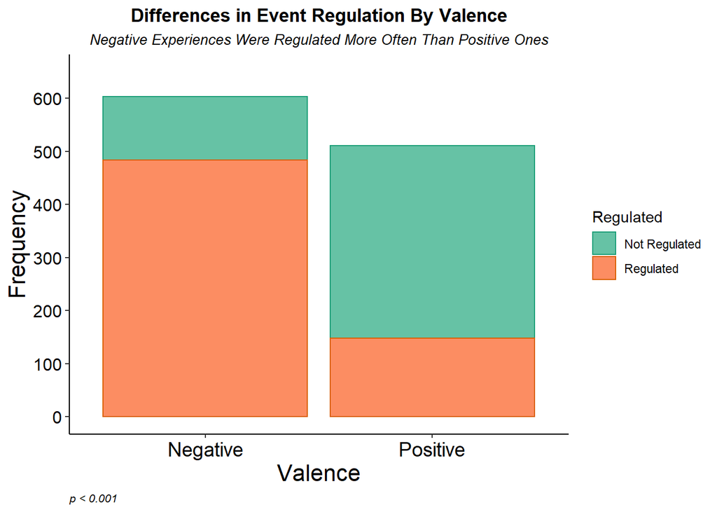

```r
ggplot(data = df, aes(x = Valence, color = Regulated, fill = Regulated)) + #NOTE: We do not have a Y variable, but we noted Regulated as a sort of moderator
    geom_bar() + #Geom_bar allows us to produce the bar geoms
    scale_x_discrete("Valence", breaks = c("Negative", "Positive")) + #This command allows us to add labels to the x axis
    scale_y_continuous(breaks = c(0,100,200,300,400,500,600)) + #This command dictates what points we can visually see on the scale.
    scale_color_brewer(palette = "Dark2") + #This command dictates what color outlines our geoms
    scale_fill_brewer(palette = "Set2") + #This command dictates what colors fill our geoms
    labs(title = "Differences in Event Regulation By Valence",
       subtitle = "Negative Experiences Were Regulated More Often Than Positive Ones",
       x =NULL,
       y ="Frequency",
       caption = "p < 0.001") + #In the caption, I chose to note the outcome of the statistical test
    coord_cartesian(ylim=c(0.0, 650.0)) +
    theme_classic() +
    theme(plot.title = element_text(face="bold", size=13, hjust = 0.5)) +
    theme(plot.subtitle = element_text(size = 10, hjust = 0.5, face = "italic")) +
    theme(plot.caption = element_text(size = 8, hjust = 0.0, face = "italic")) +
    theme(axis.title = element_text(size = 16)) +
    theme(axis.text.x = element_text(size = 14, color = "Black")) +
    theme(axis.text.y = element_text(size = 12, color = "Black"))
```

You’ll first notice that we have no Y variable, because the dependent variable in a chi square test is frequency. We do note the importance of the Regulated variable in the color and fill commands of the first line, meaning that our geoms will have unique colors based upon what category of “Regulated” they fall under. In the context of a geom_bar plot, the color argument will inform geom outlines, while fill will inform geom fill colors. So, as you can see, "Not regulated events, are represented by an aqua fill with a slightly darker aqua outline, while Regulated events are represented by a peach color with a darker peach outline. We truly don’t need both the fill and the outline; I just wanted to demonstrate both, and I kind of think it looks nice.

Moving on, we see the bar_geom which is new for us. We could provide many of the same commands we’d provided to geom_smooth, including size and color, but the defaults in R tend to work fine for the geom_bar command.

Following our geom, we see a new class of commands which we have not used before: scales. Scales affect our axes and follow a simple format. In this case, we use scale_x_discrete because our x axis is representing qualitative data. Had X been representing quantitative data, we would use the scale_x_continuous command instead. As you can see, we use that command on our Y axis, which is representing quantiative data (i.e., frequency). These commands will allow us to set labels and decide what values we can visually see (using the breaks command). If you remember I’d mentioned in a previous lecture that we may sometimes give GGplot conflicting commands, in which case, it will choose the latter. This is the most common culprit if you also use the labs function like I do. The labs function, unfortunately, won’t allow me to name the individuals bars, though; so while I could name the X axis “Valence”, I wouldn’t be able to label the two bars as Negative and Positive, which is why this command is necessary. Using the scale_y_continuous function, I can tell R that I specifically want to see tick marks for the values listed.

Similarly, in the scale family of functions, we see scale_color_brewer and scale_fill_brewer. These are both products of the RColorBrewer package and allow us to note which palettes from the package that we want to use to color the outline and the fill.

All other elements had been covered in our previous review of the anatomy of a ggplot.

# —– One Sample T-Test Plots —–

Another common statistical test we might run into is that of the one-sample t-test in which we want to determine whether the mean of a sample is substantially different from mu (typically set at 0). In this particular example, we’re going to want to know whether the haunted house we put people through sufficiently elicited emotion, so we’re measuring whether positive and negative intensity were statistically significant from 1 (which I’ve noted in the caption).

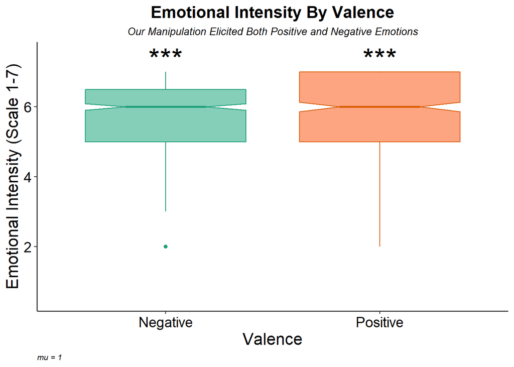

```r
Plot <- ggplot(df, aes(x = Valence, y = Emo.Extent, color = Valence, fill = Valence)) + #Note that we do have a Y variable here
    geom_boxplot(notch = T, alpha= 0.8) + # Note that we are using a geom_boxplot
    geom_signif(textsize = 10, annotations = "***", y_position = 7, xmin = 1, xmax = 1, tip_length = 0, color = "Black") + # Note that we have not see this argument in the past
    geom_signif(textsize = 10, annotations = "***", y_position = 7, xmin = 2, xmax = 2, tip_length = 0, color = "Black") +
    scale_x_discrete("Valence", breaks = c("Negative", "Positive")) +
    scale_color_brewer(palette = "Dark2") +
    scale_fill_brewer(palette = "Set2") +
    labs(title = "Emotional Intensity By Valence",
       subtitle = "Our Manipulation Elicited Both Positive and Negative Emotions",
       x =NULL,
       y ="Emotional Intensity (Scale 1-7)",
       caption = "mu = 1") +
    coord_cartesian(ylim=c(.5, 7.5)) +
    theme_classic() +
    theme(legend.position="none") +
    theme(plot.title = element_text(face="bold", size=16, hjust = 0.5)) +
    theme(plot.subtitle = element_text(size = 10, hjust = 0.5, face = "italic")) +
    theme(plot.caption = element_text(size = 8, hjust = 0.0, face = "italic")) +
    theme(axis.title = element_text(size = 16)) +
    theme(axis.text.x = element_text(size = 14, color = "Black")) +
    theme(axis.text.y = element_text(size = 14, color = "Black"))
  Plot
```

# —– Two-Sample T-Test & ANOVA Plots —–

Now we’re going to move on to a slightly more complex visualization; that being two-sample t-tests with 95% confidence intervals included. There are a lot of ways to approach the isuses of error bars. As best as I can tell, ggplot does not have a native function to accurately estimate 95% confidence intervals (though it will do standard error). As such we’re going to briefly dive into the realm of custom built functions. You don’t need to understand what’s going on in the following lines of code. You can just know that it will create a new dataframe from our original dataframe that captures both the mean and 95% confidence intervals.

```r
Summary <- function(data=NULL, measurevar, groupvars=NULL, na.rm=FALSE,
                      conf.interval=.95, .drop=TRUE) {
  length2 <- function (x, na.rm=FALSE) {
    if (na.rm) sum(!is.na(x))
    else       length(x)
  }
  datac <- ddply(data, groupvars, .drop=.drop,
                 .fun = function(xx, col) {
                   c(N    = length2(xx[[col]], na.rm=na.rm),
                     mean = mean   (xx[[col]], na.rm=na.rm),
                     sd   = sd     (xx[[col]], na.rm=na.rm))
                 },
                 measurevar
  )
  datac <- plyr::rename(datac, c("mean" = measurevar))
  datac$se <- datac$sd / sqrt(datac$N)
  ciMult <- qt(conf.interval/2 + .5, datac$N-1)
  datac$ci <- datac$se * ciMult
  return(datac)
}
```

Once that code is ran, we have a custom function R is ready to use. We can use it with the following code:

```r
Summary <- Summary(data = df, measurevar = "Emo.Extent", groupvars = "Valence")
```

I believe each argument is fairly self-explanatory, but we can view the dataframe to get a better sense of what it just did:

```r
head(Summary)
```

|  | Valence | N | Emo.Extent | sd | se | ci |
| --- | --- | --- | --- | --- | --- | --- |
| 1 | Negative | 603 | 5.439469 | 1.243281 | 0.05063033 | 0.09943354 |
| 2 | Positive | 511 | 5.900196 | 1.189752 | 0.05263153 | 0.10340129 |

So now we have the sample size, mean, standard deviation, standard error, and confidence interval of the emotional intensity for both positive and negative emotions.

Often times, for t-tests, we represent the data using bar graphs. However, many researchers have moved away from bar graphs due to tendencies to misinterpret the data in favor of alternatives, like point-line plots. We will be using a point-line plot here, but if you wanted to use a more traditional bar plot, instead, you could substitute the stat_summary argument with geom_bar().

This will modify our plot as such:

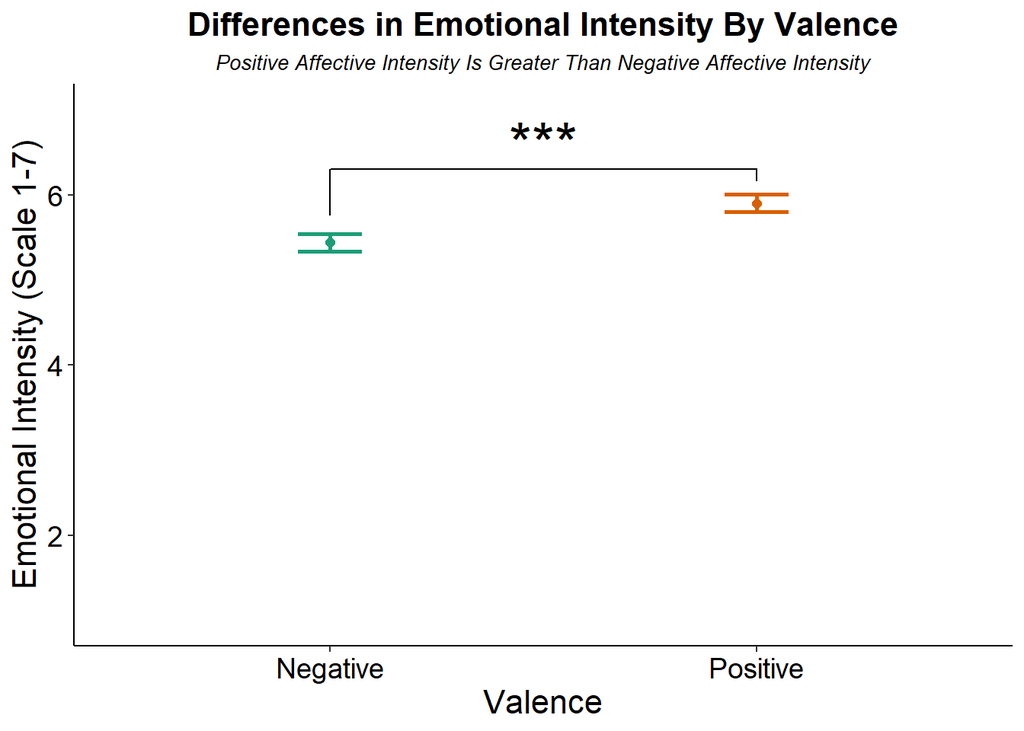

```r
ggplot(data = Summary, aes(x = Valence, y = Emo.Extent, color = Valence)) + #Note that the dataframe we reference is no longer df, but Summary
    stat_summary(geom="point", fun = mean, size = 2) + # Note that we are using a stat_summary function rather than a geom_function
    geom_errorbar(data = Summary, aes(ymin = Emo.Extent - ci, ymax = Emo.Extent + ci), size= 1, width=0.15) + #Note that we've never defined errorbars in the past
    geom_signif(textsize = 10, annotations = "***", y_position = 6.3, xmin = 1, xmax = 2, tip_length = c(.8, .2), color = "Black") + # Note that we now add a bracket to show what comparison is significant.
    scale_x_discrete("Valence", breaks = c("Negative", "Positive")) +
    scale_color_brewer(palette = "Dark2") +
    labs(title = "Differences in Emotional Intensity By Valence",
       subtitle = "Positive Affective Intensity Is Greater Than Negative Affective Intensity",
       x =NULL,
       y ="Emotional Intensity (Scale 1-7)",
       caption = NULL) +
    coord_cartesian(ylim=c(1.0, 7.0)) +
    theme_classic() +
    theme(legend.position="none") +
    theme(plot.title = element_text(face="bold", size=16, hjust = 0.5)) +
    theme(plot.subtitle = element_text(size = 10, hjust = 0.5, face = "italic")) +
    theme(plot.caption = element_text(size = 8, hjust = 0.0, face = "italic")) +
    theme(axis.title = element_text(size = 16)) +
    theme(axis.text.x = element_text(size = 14, color = "Black")) +
    theme(axis.text.y = element_text(size = 14, color = "Black"))
```

In order to add those accurate 95% confidence intervals, we’re going to reference the Summary dataframe, not the standard df dataframe where this data originally existed. Additionally, to create the actual point at which the mean of each category exists, we use the stat_summary (or statistics summary) function, in which we first define the geom as a point, we note that it is a mean value, and define how large that point should be. We could realistically define the geom in any shape we’d like and there are many to choose from. We also see the addition of a geom_errorbar command which is where our confidence intervals come from. We can manipulate the thickness of the lines and how wide the caps are with size and width respectively. Lastly, we see that the geom_signif now produces a bracket to point to the two values it is comparing. Again, I have to manually create this via trial and error by modifying the tip_length, and xmin and xmax arguments, but I like the addition.

Please note, this custom function will not produce accurate confidence intervals if you are running a mixed effects ANOVA, as it will not differentiate between within subject and between subject effects! However, we can use it with your standard between subject ANOVA by including two grouping variables:

```r
Summary <- function(data=NULL, measurevar, groupvars=NULL, na.rm=FALSE,
                      conf.interval=.95, .drop=TRUE) {
  length2 <- function (x, na.rm=FALSE) {
    if (na.rm) sum(!is.na(x))
    else       length(x)
  }
  datac <- ddply(data, groupvars, .drop=.drop,
                 .fun = function(xx, col) {
                   c(N    = length2(xx[[col]], na.rm=na.rm),
                     mean = mean   (xx[[col]], na.rm=na.rm),
                     sd   = sd     (xx[[col]], na.rm=na.rm))
                 },
                 measurevar
  )
  datac <- plyr::rename(datac, c("mean" = measurevar))
  datac$se <- datac$sd / sqrt(datac$N)
  ciMult <- qt(conf.interval/2 + .5, datac$N-1)
  datac$ci <- datac$se * ciMult
  return(datac)
}
```

```r
Summary <- Summary(df, "Emo.Extent", c("Regulated", "Valence"))
```

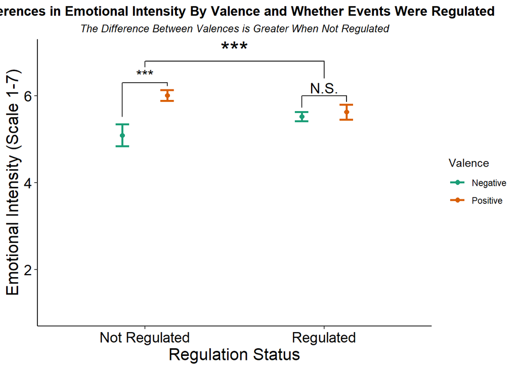

```r
ggplot(data = Summary, aes(x = Regulated, y = Emo.Extent, color = Valence)) + #Note that we replace the X var with the newly introduced variable
    stat_summary(geom="point", fun = mean, size = 2, position = position_dodge(width = 0.5)) + #Note the addition of the position argument
    geom_errorbar(data = Summary, aes(ymin = Emo.Extent - ci, ymax = Emo.Extent + ci), size= 1, width=0.15, position = position_dodge(width = 0.5)) + #Note the addition of the position argument
    geom_signif(textsize = 8, annotations = "***", y_position = 6.8, xmin = 1, xmax = 2, tip_length = c(.1, .3), color = "Black") +
    geom_signif(textsize = 5, annotations = "***", y_position = 6.3, xmin = .875, xmax = 1.125, tip_length = c(.6 , .05), color = "Black") +
    geom_signif(textsize = 5, annotations = "N.S.", y_position = 6.0, xmin = 1.875, xmax = 2.125, tip_length = c(.2, .1), color = "Black") +
    scale_x_discrete("Regulation Status", breaks = c("Not Regulated", "Regulated")) +
    scale_y_continuous(breaks = c(2,4,6)) +
    labs(title = "Differences in Emotional Intensity By Valence and Whether Events Were Regulated",
       subtitle = "The Difference Between Valences is Greater When Not Regulated",
       x =NULL,
       y ="Emotional Intensity (Scale 1-7)",
       caption = NULL) +
    scale_color_brewer(palette = "Dark2") +
    coord_cartesian(ylim=c(1.0, 7.0)) +
    theme_classic() +
    theme(plot.title = element_text(face="bold", size=13, hjust = 0.5)) +
    theme(plot.subtitle = element_text(size = 10, hjust = 0.5, face = "italic")) +
    theme(plot.caption = element_text(size = 8, hjust = 0.0, face = "italic")) +
    theme(axis.title = element_text(size = 16)) +
    theme(axis.text.x = element_text(size = 14, color = "Black")) +
    theme(axis.text.y = element_text(size = 14, color = "Black"))
```

The most notable addition in this plot is the position = point_dodge command, which is what tells R to spatially separate the valenced means around the regulated and not regulated columns. If we did not include that argument, the two would occupy the same space:

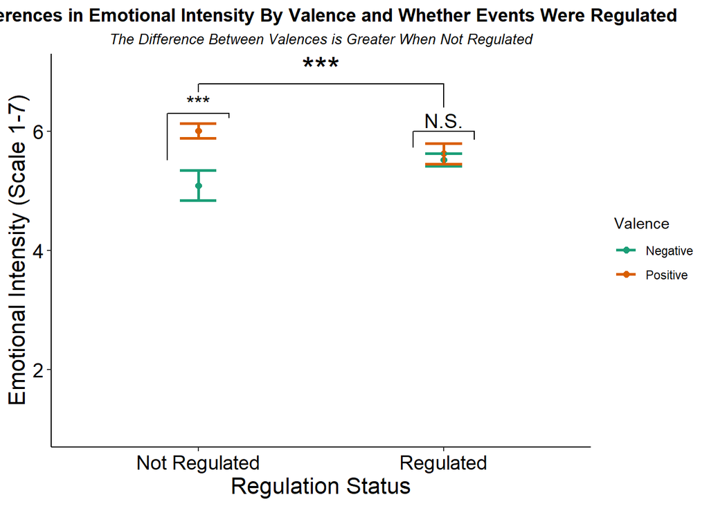

```r
ggplot(data = Summary, aes(x = Regulated, y = Emo.Extent, color = Valence)) +
    stat_summary(geom="point", fun = mean, size = 2) + #Note the lack of the position argument
    geom_errorbar(data = Summary, aes(ymin = Emo.Extent - ci, ymax = Emo.Extent + ci), size= 1, width=0.15) + #Note the lack of the position argument
    geom_signif(textsize = 8, annotations = "***", y_position = 6.8, xmin = 1, xmax = 2, tip_length = c(.1, .3), color = "Black") +
    geom_signif(textsize = 5, annotations = "***", y_position = 6.3, xmin = .875, xmax = 1.125, tip_length = c(.6 , .05), color = "Black") +
    geom_signif(textsize = 5, annotations = "N.S.", y_position = 6.0, xmin = 1.875, xmax = 2.125, tip_length = c(.2, .1), color = "Black") +
    scale_x_discrete("Regulation Status", breaks = c("Not Regulated", "Regulated")) +
    scale_y_continuous(breaks = c(2,4,6)) +
    labs(title = "Differences in Emotional Intensity By Valence and Whether Events Were Regulated",
       subtitle = "The Difference Between Valences is Greater When Not Regulated",
       x =NULL,
       y ="Emotional Intensity (Scale 1-7)",
       caption = NULL) +
    scale_color_brewer(palette = "Dark2") +
    coord_cartesian(ylim=c(1.0, 7.0)) +
    theme_classic() +
    theme(plot.title = element_text(face="bold", size=13, hjust = 0.5)) +
    theme(plot.subtitle = element_text(size = 10, hjust = 0.5, face = "italic")) +
    theme(plot.caption = element_text(size = 8, hjust = 0.0, face = "italic")) +
    theme(axis.title = element_text(size = 16)) +
    theme(axis.text.x = element_text(size = 14, color = "Black")) +
    theme(axis.text.y = element_text(size = 14, color = "Black"))
```

# —– Exercise —–

Let’s pretend we wanted to visualize the results of an ANOVA which examined the whether there were differences in regulation extent (Reg.Extent) by the regulation strategy used (Strat.Cat) and the valence of the emotional experience (Valence). Ignoring labeling, how might we visualize that, using the templates we’d reviewed in this section?

# 6.0. Examples of Visualizations w/ Quantitative Independent Variables

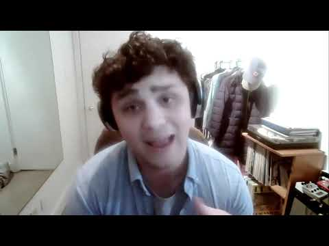

This section should be quick, because we’d been reviewing some regression examples in earlier sections. In general, I find the range of ease in creating regression visualizations in ggplot2 to be very wide. On one hand, ggplot makes bivariate and multivariate linear regression a breeze to produce. On the other hand, I once spend about a week straight trying to figure out how to reliably produce binary logistic regressions in R as conveniently as I could in SPSS. Hopefully, having all of these templates in one place will save you the trouble in the future, should you ever need to run any of these.

# —– Bivariate Linear Regression Plots —–

We are going to start by producing a fairly straight forward bivariate linear regression visualizing the relationship between the intensity of an emotional experience and how much effort the person put into trying to regulate that emotional experience. In order to spice things up a bit (in the most mild lecture possible), we’re going to try visualizing the individual datapoints that influence the trajectory of the regression line:

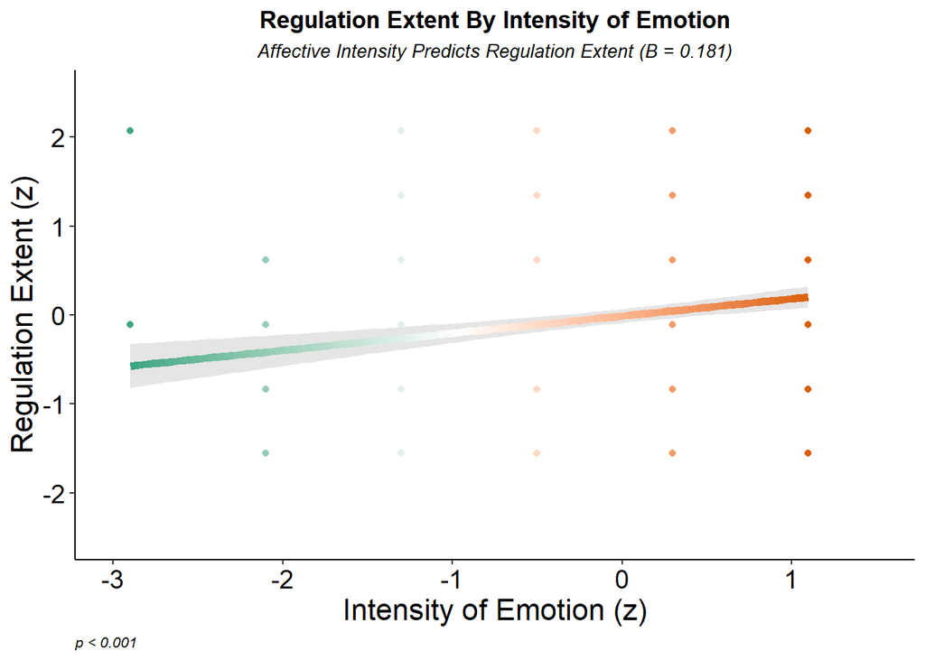

```r
ggplot(data = df, aes(x = Emo.Extent.z, y = Reg.Extent.z, color = Emo.Extent.z)) +
    stat_smooth(aes(color = ..x..), method="lm", alpha = .25, size = 2) +
    geom_point()+ # We added this argument
    scale_x_continuous(breaks = c(-3,-2,-1,0,1)) +
    scale_y_continuous(breaks = c(-2,-1,0,1,2)) +
    scale_color_gradient2(low = "#1B9E77", high = "#D95F02", midpoint = median(-1)) +
    labs(title = "Regulation Extent By Intensity of Emotion",
       subtitle = "Affective Intensity Predicts Regulation Extent (B = 0.181)",
       x = "Intensity of Emotion (z)",
       y ="Regulation Extent (z)",
       caption = "p < 0.001") +
    coord_cartesian(xlim=c(-3.0, 1.5), ylim=c(-2.5, 2.5)) +
    theme_classic() +
    theme(legend.position="none") +
    theme(plot.title = element_text(face="bold", size=13, hjust = 0.5)) +
    theme(plot.subtitle = element_text(size = 10, hjust = 0.5, face = "italic")) +
    theme(plot.caption = element_text(size = 8, hjust = 0.0, face = "italic")) +
    theme(axis.title = element_text(size = 16)) +
    theme(axis.text.x = element_text(size = 14, color = "Black")) +
    theme(axis.text.y = element_text(size = 14, color = "Black"))
```

# —– Jittering Datapoints —–

And it’s that simple! Just by adding the geom_point command, we can see where out data points are in the same gradient as our regression line. However, we still don’t have a sense for the density of the distribution. How many datapoints are actually catured at each point? One solution is to add a slight bit of randomness to the position of the data points such that they are no longer overlapping (i.e., jittering). We’re gonna run the same code with a slight tweak:

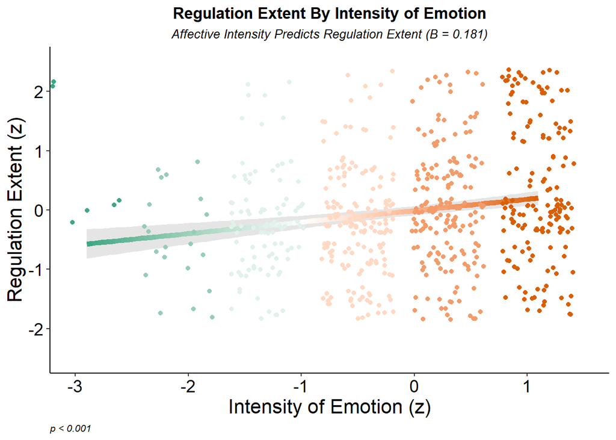

```r
ggplot(data = df, aes(x = Emo.Extent.z, y = Reg.Extent.z, color = Emo.Extent.z)) +
    stat_smooth(aes(color = ..x..), method="lm", alpha = .25, size = 2) +
    geom_point(position = "jitter")+ #We've modified this argument
    scale_x_continuous(breaks = c(-3,-2,-1,0,1)) +
    scale_y_continuous(breaks = c(-2,-1,0,1,2)) +
    scale_color_gradient2(low = "#1B9E77", high = "#D95F02", midpoint = median(-1)) +
    labs(title = "Regulation Extent By Intensity of Emotion",
       subtitle = "Affective Intensity Predicts Regulation Extent (B = 0.181)",
       x = "Intensity of Emotion (z)",
       y ="Regulation Extent (z)",
       caption = "p < 0.001") +
    coord_cartesian(xlim=c(-3.0, 1.5), ylim=c(-2.5, 2.5)) +
    theme_classic() +
    theme(legend.position="none") +
    theme(plot.title = element_text(face="bold", size=13, hjust = 0.5)) +
    theme(plot.subtitle = element_text(size = 10, hjust = 0.5, face = "italic")) +
    theme(plot.caption = element_text(size = 8, hjust = 0.0, face = "italic")) +
    theme(axis.title = element_text(size = 16)) +
    theme(axis.text.x = element_text(size = 14, color = "Black")) +
    theme(axis.text.y = element_text(size = 14, color = "Black"))
```

Now we can actually see how negatively skewed this dataset is! Alternatively, we could have just wrote geom_jitter() and gotten the same result. Now also, note that we see an exmaple of ggplot building this visual in sequential layers. Because we added the geom points after the command for the regression line, they sit on top of the regression line. If we wanted to reverse that, we should list the geom_point command first, followed by the regression line arguments.

# —– Moderation & Multivariate Linear Regression Plots —–

Once again, we’ve already taken a look at moderation visualizations, so there’s nothing within this code that should be totally new to us. Note that we are running the same analysis as above, but we’re seeing whether valence moderates the relationship, so the relationship between intensity and regulation may be different for positive and negative emotions. Just to spice things up a little, I’m going to modify the size and shape of the geom points and add a fill color that’s based on valence:

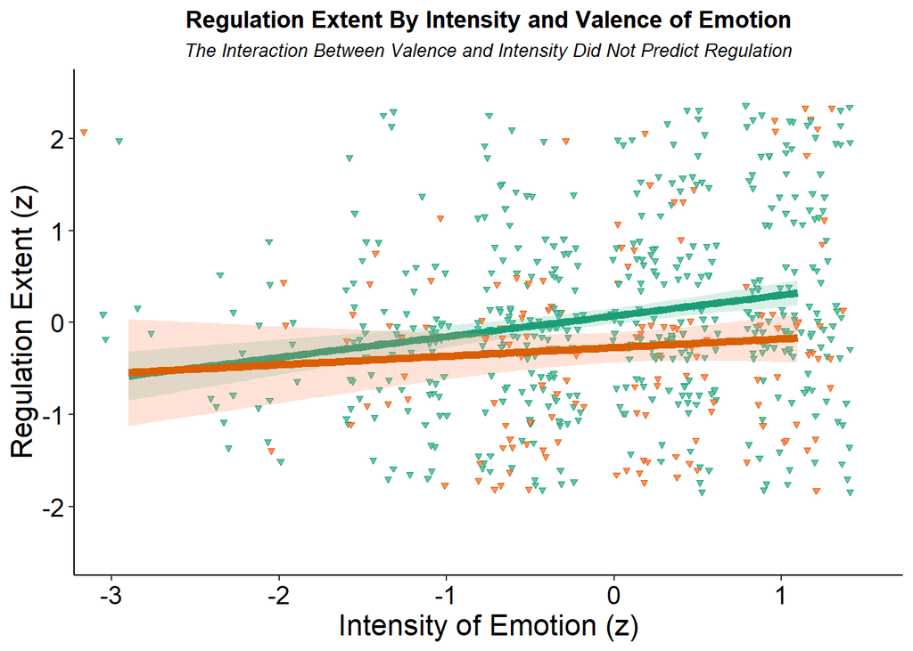

```r
ggplot(data = df, aes(x = Emo.Extent.z, y = Reg.Extent.z, fill = Valence, group = Valence, color = Valence)) + # We added a fill argument here
    geom_jitter(size = 1, shape = 25) + #We added the size and shape arguments
    stat_smooth(aes(color = Valence), method="lm", alpha = .25, size = 2) +
    scale_x_continuous(breaks = c(-3,-2,-1,0,1)) +
    scale_y_continuous(breaks = c(-2,-1,0,1,2)) +
    scale_color_brewer("Valence", labels= c("Negative", "Positive"), palette = "Dark2") +
    scale_fill_brewer("Valence", labels= c("Negative", "Positive"), palette = "Set2") + # We added this function
    labs(title = "Regulation Extent By Intensity and Valence of Emotion",
       subtitle = "The Interaction Between Valence and Intensity Did Not Predict Regulation",
       x = "Intensity of Emotion (z)",
       y ="Regulation Extent (z)",
       caption = NULL) +
    coord_cartesian(xlim=c(-3.0, 1.5), ylim=c(-2.5, 2.5)) +
    theme_classic() +
    theme(legend.position="none") +
    theme(plot.title = element_text(face="bold", size=13, hjust = 0.5)) +
    theme(plot.subtitle = element_text(size = 10, hjust = 0.5, face = "italic")) +
    theme(plot.caption = element_text(size = 8, hjust = 0.0, face = "italic")) +
    theme(axis.title = element_text(size = 16)) +
    theme(axis.text.x = element_text(size = 14, color = "Black")) +
    theme(axis.text.y = element_text(size = 14, color = "Black"))
```

As you can clearly see, we have different shaped points now and the Set2 Palette has affected the fill of those points, as well as the standard error ribbon. You might notice that I entered “25” to get the upside down triangles I did. Unfortunately, as best as I can tell, what shape corresponds to which number is completely aribtrary. When I need to know what number I need, I usually just google “geom_point shapes”. None of that is very important to the bones of a moderation analysis visualization. What I do want to note is that there are far simpler ways to visualize moderation analyses. We could run ggplot without all the extra fluff I like to include, but we could also use the interaction package to get a super quick copy of what we saw above (assuming that we’ve run the model already):

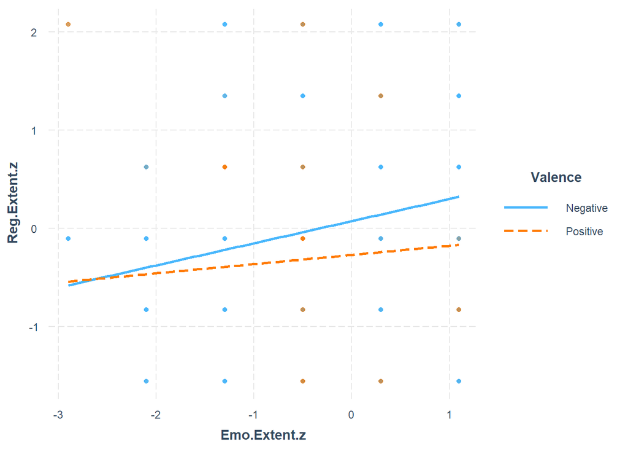

```r
m1 <- lm(Reg.Extent.z ~ Emo.Extent.z * Valence, data = df)
interact_plot(m1, pred = Emo.Extent.z, modx = Valence, plot.points = TRUE)
```

interaction will allow us to get a little more complicated if we want with additional arguments:

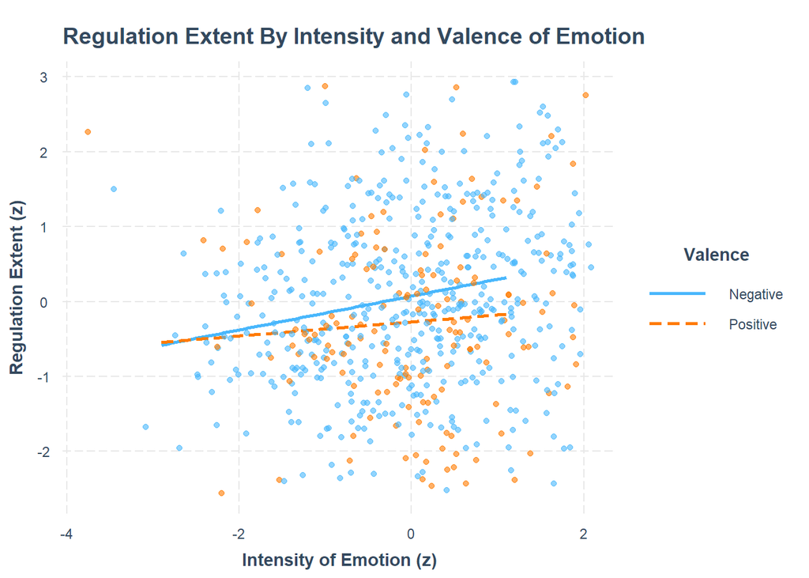

```r
m1 <- lm(Reg.Extent.z ~ Emo.Extent.z * Valence, data = df)
interact_plot(m1,
              pred = Emo.Extent.z,
              modx = Valence,
              plot.points = TRUE,
              x.label = "Intensity of Emotion (z)",
              y.label = "Regulation Extent (z)",
              jitter = TRUE,
              main.title = "Regulation Extent By Intensity and Valence of Emotion")
```

It’s more simplistic, but we could also use the native plot capabilities of R and see the relationships faceted:

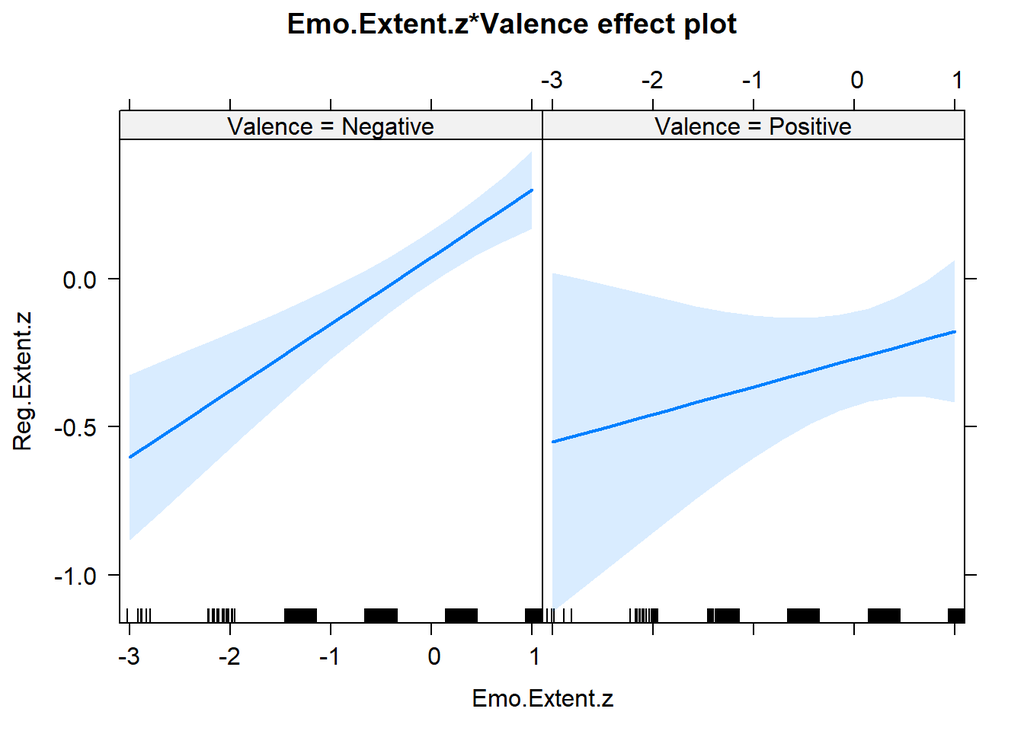

```r
m1 <- lm(Reg.Extent.z ~ Emo.Extent.z * Valence, data = df)
plot(effect("Emo.Extent.z:Valence", m1, grid = TRUE))
```

# —– Binary Logistic Regression Plots —–

Alright, now we’ve gotten through the simple stuff. We’re going to move on to binary logistic regression, which honestly isn’t very complex either (once you know the solution). In order to do this effectively, we need to pull in the effects package in order to plot the probabilities which are characteristics of a binary logistic regression. In effect this, is going to be very similar to the custom Summary function we used to plot t-tests and ANOVAs. We also need a slightly modified version of the dataframe we’ve already been using.

```r
   load("C:/Users/Administrator/Google_Drive/COG/cog_summer_workshops_2021/data-visualization-in-r/Dataframes/df3.rda")
```

We must first plot the formula of the binary logistic regression that we want to measure. For those who may be unfamiliar with this type of analysis, we use a quantitative predictor to determine a binary outcome. In this case, we are determining whether the intensity of an emotional experience increases the probability of choosing a specific regulation strategy (Either reappraisal or disengagement).

```r
m1 <- glm(Strat.Cat ~ Emo.Extent.z, data = df, family = binomial)
```

We then have the effect package predict the probability of either outcome at various levels of the variable Emo.Extent.z. Because this is Z-Scored, I chose values in increments of 0.01 between -3 and +3, but you could subsequent whatever values fit the range of your predictor variable. We then must convert the resulting product into a dataframe:

```r
m1.e <- effect("Emo.Extent.z", m1 , xlevels=list(Emo.Extent.z = seq(-3.0,3.0,0.01)))
m1.e <-as.data.frame(m1.e)
```

Then, we are going to use said dataframe as the source for our plot. Our criteron variable is the fitted probability of choosing either binary outcomes, which the effects package fittingly always names “fit”. We the simply call for a geom_line and geom_ribbon, and the rest is largely the same:

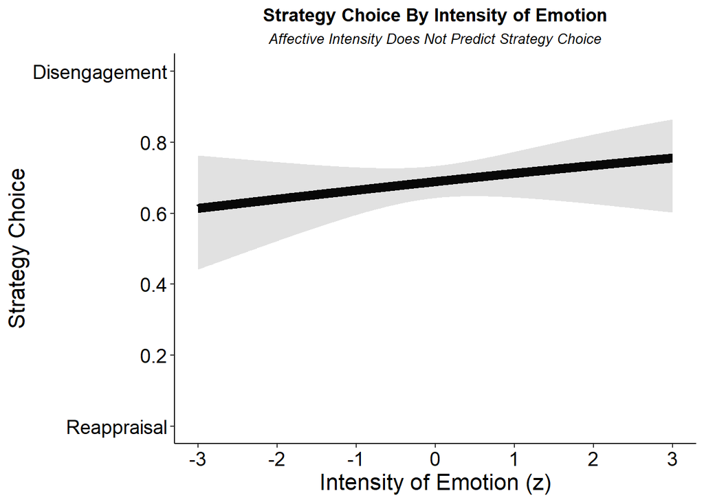

```r
ggplot(data = m1.e, aes(x = Emo.Extent.z, y = fit)) + #Dataframe and y variable are new
    geom_line(size = 3) + #This is a new addition
    geom_ribbon(aes(ymin=lower, ymax=upper), alpha = 0.15) + #This is a new addition; we set the upper and lower limits to "upper" and "lower" which are automatically defined in our effects dataframe.
    scale_x_continuous(breaks = seq(-3,3,1)) +
    scale_y_continuous(labels = c("Reappraisal", "0.2", "0.4", "0.6", "0.8","Disengagement"), breaks = seq(0,1,0.2)) +
    labs(title = "Strategy Choice By Intensity of Emotion",
       subtitle = "Affective Intensity Does Not Predict Strategy Choice",
       x = "Intensity of Emotion (z)",
       y ="Strategy Choice",
       caption = NULL) +
    coord_cartesian(xlim=c(-3.0, 3.0), ylim=c(0,1)) +
    theme_classic() +
    theme(legend.position="none") +
    theme(plot.title = element_text(face="bold", size=13, hjust = 0.5)) +
    theme(plot.subtitle = element_text(size = 10, hjust = 0.5, face = "italic")) +
    theme(plot.caption = element_text(size = 8, hjust = 0.0, face = "italic")) +
    theme(axis.title = element_text(size = 16)) +
    theme(axis.text.x = element_text(size = 14, color = "Black")) +
    theme(axis.text.y = element_text(size = 14, color = "Black"))
```

The resulting plot doesn’t look much like that traditional S curve we see in binary logistic regression, but that’s because we failed to support our hypothesis. If we zoom out by modifying the range of our effects dataframe and the scope of our coord_cartesian command . . .

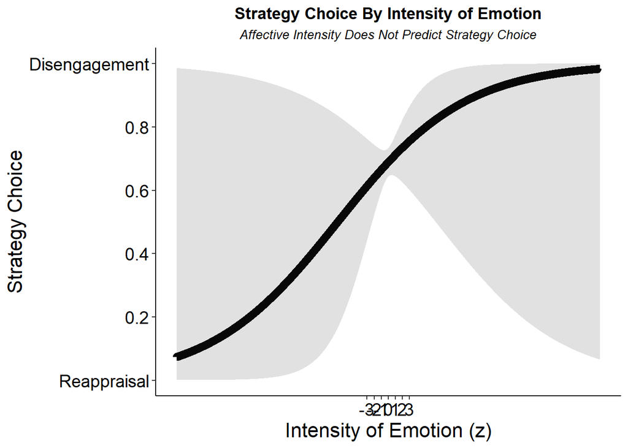

```r
m1.e <- effect("Emo.Extent.z", m1 , xlevels=list(Emo.Extent.z = seq(-30.0,30.0,0.01)))
m1.e <-as.data.frame(m1.e)
ggplot(data = m1.e, aes(x = Emo.Extent.z, y = fit)) + #Dataframe and y variable are new
    geom_line(size = 3) + #This is a new addition
    geom_ribbon(aes(ymin=lower, ymax=upper), alpha = 0.15) + #This is a new addition; we set the upper and lower limits to "upper" and "lower" which are automatically defined in our effects dataframe.
    scale_x_continuous(breaks = seq(-3,3,1)) +
    scale_y_continuous(labels = c("Reappraisal", "0.2", "0.4", "0.6", "0.8","Disengagement"), breaks = seq(0,1,0.2)) +
    labs(title = "Strategy Choice By Intensity of Emotion",
       subtitle = "Affective Intensity Does Not Predict Strategy Choice",
       x = "Intensity of Emotion (z)",
       y ="Strategy Choice",
       caption = NULL) +
    coord_cartesian(xlim=c(-30.0, 30.0), ylim=c(0,1)) +
    theme_classic() +
    theme(legend.position="none") +
    theme(plot.title = element_text(face="bold", size=13, hjust = 0.5)) +
    theme(plot.subtitle = element_text(size = 10, hjust = 0.5, face = "italic")) +
    theme(plot.caption = element_text(size = 8, hjust = 0.0, face = "italic")) +
    theme(axis.title = element_text(size = 16)) +
    theme(axis.text.x = element_text(size = 14, color = "Black")) +
    theme(axis.text.y = element_text(size = 14, color = "Black"))
```

We see that we would have to have VERY Intense emotional reactions in order for intensity to predict strategy choice. Hopefully your hypotheses don’t suffer from the same fate that this one had!

Adding moderators isn’t much more complicated than what we’d done in the past. We need to respecify our formula:

```r
m2 <- glm(Strat.Cat ~ Emo.Extent.z * Valence, data = df, family = binomial)
```

Rerun the effects command based on that new formula and based upon the effect of the interaction:

```r
m2.e <- effect("Emo.Extent.z:Valence",m2,xlevels=list(Emo.Extent.z=seq(-3.0,3.0,0.01)))
m2.e <-as.data.frame(m2.e)
```

and then just add the group and color arguments within the first line (with an additional scale_color_brewer command if you want to differentiate between them):

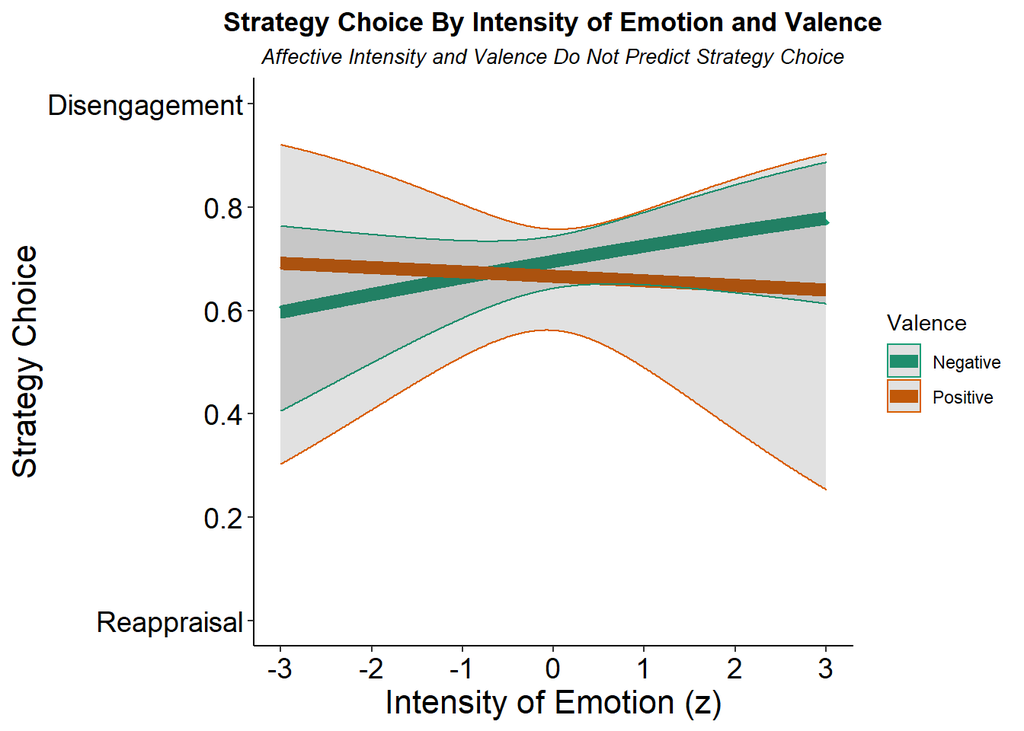

```r
ggplot(data = m2.e, aes(x = Emo.Extent.z, y = fit, group = Valence, color = Valence)) + # We added group and color here
    geom_line(size = 3) +
    geom_ribbon(aes(ymin=lower, ymax=upper), alpha = 0.15) +
    scale_x_continuous(breaks = seq(-3,3,1)) +
    scale_y_continuous(labels = c("Reappraisal", "0.2", "0.4", "0.6", "0.8","Disengagement"), breaks = seq(0,1,0.2)) +
    scale_color_brewer(palette = "Dark2")+ # We added this to differentiate.
    labs(title = "Strategy Choice By Intensity of Emotion and Valence",
       subtitle = "Affective Intensity and Valence Do Not Predict Strategy Choice",
       x = "Intensity of Emotion (z)",
       y ="Strategy Choice",
       caption = NULL) +
    coord_cartesian(xlim=c(-3.0, 3.0), ylim=c(0,1)) +
    theme_classic() +
    theme(plot.title = element_text(face="bold", size=13, hjust = 0.5)) +
    theme(plot.subtitle = element_text(size = 10, hjust = 0.5, face = "italic")) +
    theme(plot.caption = element_text(size = 8, hjust = 0.0, face = "italic")) +
    theme(axis.title = element_text(size = 16)) +
    theme(axis.text.x = element_text(size = 14, color = "Black")) +
    theme(axis.text.y = element_text(size = 14, color = "Black"))
```

# Conclusion

[figure not shown]